# Discrete Probability Distributions

Marti

October 22, 2025

## Introducción

Este cuaderno reúne la teoría y simulaciones prácticas de cuatro distribuciones discretas fundamentales: uniforme discreta, Bernoulli, binomial e hipergeométrica. Para cada distribución revisamos la función de masa de probabilidad (pmf), el valor esperado y la varianza, y luego ejecutamos dos o tres simulaciones breves que muestran cómo se comportan en la práctica las muestras aleatorias. Todas las simulaciones se basan en los generadores de números aleatorios de R base (`sample()`, `rbinom()` y `rhyper()`), y cada una incluye visualizaciones que comparan las frecuencias relativas simuladas con las probabilidades teóricas correspondientes.

## Distribución uniforme discreta

### Teoría

La distribución uniforme discreta asigna la misma probabilidad a cada elemento de un conjunto finito. Si $X$ toma valores en ${a, a+1, \ldots, b}$ con $n = b - a + 1$ resultados posibles, entonces

$$P(X = x) = \frac{1}{n}, \qquad x \in {a, \ldots, b}.$$

Su esperanza y varianza son

$$\mathbb{E}[X] = \frac{a + b}{2}, \qquad \operatorname{Var}(X) =
\frac{n^2 - 1}{12}.$$

Este modelo aplica cuando se selecciona un elemento de manera uniforme al azar, como al lanzar un dado o elegir un día al azar dentro de una línea de tiempo corta.

### Ejemplo 1: lanzar un dado justo

Generamos $10000$ muestras de un dado justo de seis caras y comparamos las frecuencias simuladas con la probabilidad teórica de $1/6$.

```r
n_rolls <- 10000
die_rolls <- sample(1:6, size = n_rolls, replace = TRUE)
die_distribution <- tibble(face = factor(die_rolls, levels = 1:6)) %>%
  count(face) %>%
  mutate(relative_freq = n / sum(n))

die_distribution
```

```
## # A tibble: 6 × 3
##   face      n relative_freq
##   <fct> <int>         <dbl>
## 1 1      1654         0.165
## 2 2      1628         0.163
## 3 3      1668         0.167
## 4 4      1685         0.168
## 5 5      1678         0.168
## 6 6      1687         0.169
```

La media y la varianza muestrales se aproximan a los valores teóricos.

```r
die_summary <- tibble(
  sample_mean = mean(die_rolls),
  sample_variance = var(die_rolls),
  theoretical_mean = mean(1:6),
  theoretical_variance = ((6 - 1 + 1)^2 - 1) / 12
)
die_summary
```

```
## # A tibble: 1 × 4
##   sample_mean sample_variance theoretical_mean theoretical_variance
##         <dbl>           <dbl>            <dbl>                <dbl>
## 1        3.52            2.92              3.5                 2.92
```

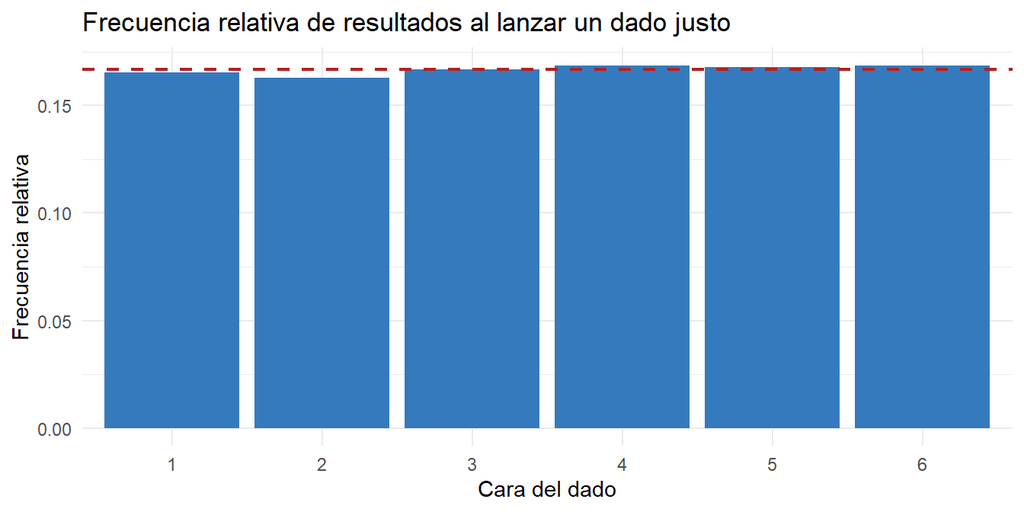

```r
ggplot(die_distribution, aes(x = face, y = relative_freq)) +
  geom_col(fill = "#357ABD") +
  geom_hline(yintercept = 1 / 6, linetype = "dashed", color = "firebrick", linewidth = 0.8) +
  labs(
    title = "Frecuencia relativa de resultados al lanzar un dado justo",
    x = "Cara del dado",
    y = "Frecuencia relativa"
  )
```

### Ejemplo 2: Día de mantenimiento aleatorio

Imagina programar un día de mantenimiento de manera uniforme entre los primeros 20 días de un mes. Generamos $5000$ días aleatorios y los comparamos con la probabilidad teórica de $1/20$.

```r
n_days <- 5000
maintenance_days <- sample(1:20, size = n_days, replace = TRUE)
maintenance_distribution <- tibble(day = factor(maintenance_days, levels = 1:20)) %>%
  count(day) %>%
  mutate(relative_freq = n / sum(n))

maintenance_distribution %>% slice_head(n = 6)
```

```
## # A tibble: 6 × 3
##   day       n relative_freq
##   <fct> <int>         <dbl>
## 1 1       227        0.0454
## 2 2       275        0.055
## 3 3       260        0.052
## 4 4       226        0.0452
## 5 5       236        0.0472
## 6 6       234        0.0468
```

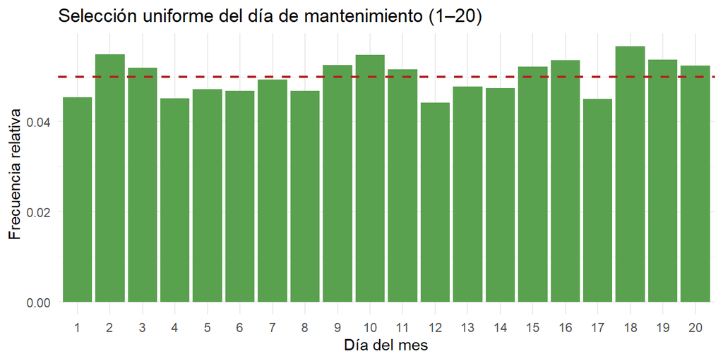

```r
ggplot(maintenance_distribution, aes(day, relative_freq)) +
  geom_col(fill = "#59A14F") +
  geom_hline(yintercept = 1 / 20, linetype = "dashed", color = "firebrick", linewidth = 0.8) +
  labs(
    title = "Selección uniforme del día de mantenimiento (1–20)",
    x = "Día del mes",
    y = "Frecuencia relativa"
  )
```

## Distribución de Bernoulli

### Teoría

La distribución de Bernoulli describe un único ensayo con dos posibles resultados: éxito (1) con probabilidad $p$ y fracaso (0) con probabilidad $1 - p$. Su pmf es

$$P(X = x) = p^x (1 - p)^{1 - x}, \qquad x \in {0, 1}.$$

La esperanza y la varianza son

$$\mathbb{E}[X] = p, \qquad \operatorname{Var}(X) = p(1 - p).$$

Cualquier decisión de sí/no con una probabilidad de éxito fija puede modelarse como Bernoulli.

### Ejemplo 1: Prueba de aprobación/fallo de un componente

Supongamos que un componente fabricado aprueba la inspección con probabilidad (p = 0.92). Simulamos (2000) pruebas para ver con qué frecuencia el componente aprueba.

```r
n_tests <- 2000
pass_prob <- 0.92
inspection_results <- rbinom(n = n_tests, size = 1, prob = pass_prob)
component_summary <- tibble(
  sample_mean = mean(inspection_results),
  sample_variance = var(inspection_results),
  theoretical_mean = pass_prob,
  theoretical_variance = pass_prob * (1 - pass_prob)
)
component_summary
```

```
## # A tibble: 1 × 4
##   sample_mean sample_variance theoretical_mean theoretical_variance
##         <dbl>           <dbl>            <dbl>                <dbl>
## 1       0.916          0.0774             0.92               0.0736
```

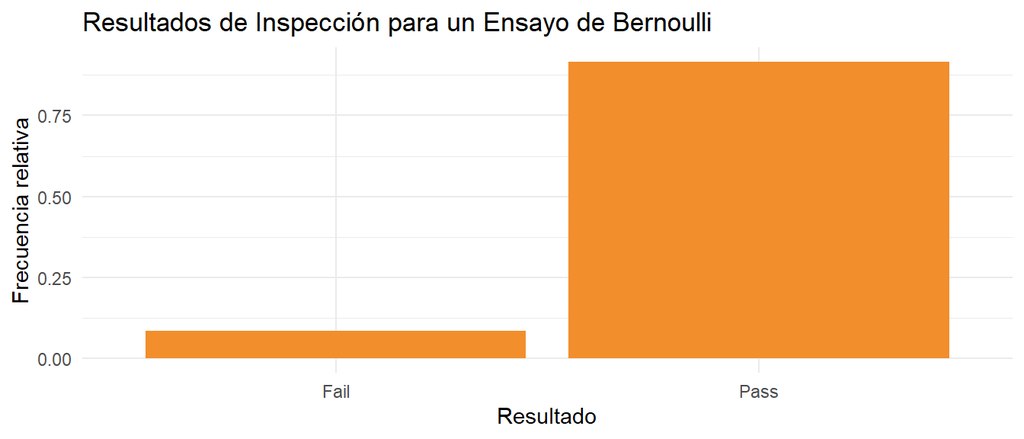

```r
inspection_distribution <- tibble(result = factor(inspection_results, levels = c(0, 1), labels = c("Fail", "Pass"))) %>%
  count(result) %>%
  mutate(relative_freq = n / sum(n))

ggplot(inspection_distribution, aes(result, relative_freq)) +
  geom_col(fill = "#F28E2B") +
  labs(
    title = "Resultados de Inspección para un Ensayo de Bernoulli",
    x = "Resultado",
    y = "Frecuencia relativa"
  )
```

### Ejemplo 2: Probabilidad de clic en un anuncio

Sea la probabilidad de que un usuario haga clic en un anuncio en línea (p = 0.15). Simulamos (5000) visitas.

```r
n_visits <- 5000
click_prob <- 0.15
clicks <- rbinom(n = n_visits, size = 1, prob = click_prob)
clicks_summary <- tibble(
  sample_mean = mean(clicks),
  theoretical_mean = click_prob
)
clicks_summary
```

```
## # A tibble: 1 × 2
##   sample_mean theoretical_mean
##         <dbl>            <dbl>
## 1       0.150             0.15
```

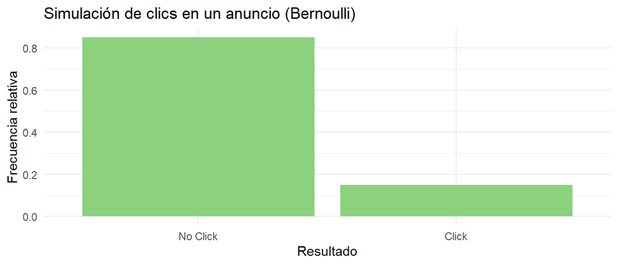

```r
click_distribution <- tibble(event = factor(clicks, levels = c(0, 1), labels = c("No Click", "Click"))) %>%
  count(event) %>%
  mutate(relative_freq = n / sum(n))

ggplot(click_distribution, aes(event, relative_freq)) +
  geom_col(fill = "#8CD17D") +
  labs(
    title = "Simulación de clics en un anuncio (Bernoulli)",
    x = "Resultado",
    y = "Frecuencia relativa"
  )
```

## Distribución binomial

### Teoría

La distribución binomial cuenta el número de éxitos en $n$ ensayos de Bernoulli independientes, cada uno con probabilidad $p$ de éxito. Para $k = 0, 1, \ldots, n$, la pmf es

$$P(X = k) = \binom{n}{k} p^k (1 - p)^{n - k}.$$

La esperanza y la varianza se derivan directamente de la suma de variables de Bernoulli independientes:

$$\mathbb{E}[X] = np, \qquad \operatorname{Var}(X) = np(1 - p).$$

Aplicaciones típicas incluyen contar el número de artículos defectuosos en un lote cuando los defectos son raros e independientes, o contabilizar éxitos en juegos repetidos.

### Ejemplo 1: tiros libres en baloncesto

Un jugador realiza (n = 10) tiros libres con probabilidad de acierto (p = 0.75). Repetimos la serie de 10 tiros (5000) veces y comparamos los conteos empíricos con la pmf binomial teórica.

```r
n_series <- 5000
n_shots <- 10
success_prob <- 0.75
made_shots <- rbinom(n = n_series, size = n_shots, prob = success_prob)

basketball_distribution <- tibble(made = made_shots) %>%
  count(made) %>%
  mutate(relative_freq = n / sum(n),
         theoretical = dbinom(made, size = n_shots, prob = success_prob))

basketball_distribution %>% slice_head(n = 6)
```

```
## # A tibble: 6 × 4
##    made     n relative_freq theoretical
##   <int> <int>         <dbl>       <dbl>
## 1     2     3        0.0006    0.000386
## 2     3    13        0.0026    0.00309
## 3     4    78        0.0156    0.0162
## 4     5   300        0.06      0.0584
## 5     6   717        0.143     0.146
## 6     7  1249        0.250     0.250
```

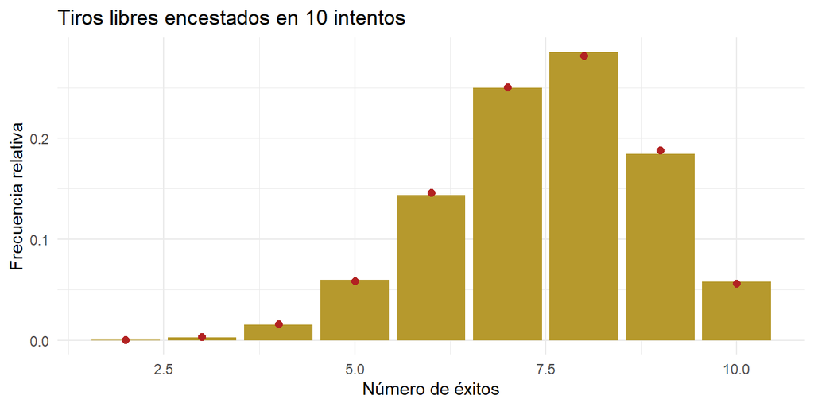

```r
ggplot(basketball_distribution, aes(made, relative_freq)) +
  geom_col(fill = "#B6992D") +
  geom_point(aes(y = theoretical), color = "firebrick", size = 2) +
  labs(
    title = "Tiros libres encestados en 10 intentos",
    x = "Número de éxitos",
    y = "Frecuencia relativa"
  )
```

### Ejemplo 2: conversiones en una campaña de correo

Supongamos que enviamos 20 correos promocionales y cada uno tiene un 20% de probabilidad de convertir. Registramos el número de conversiones a lo largo de (8000) campañas simuladas.

```r
n_campaigns <- 8000
n_emails <- 20
conversion_prob <- 0.2
conversions <- rbinom(n = n_campaigns, size = n_emails, prob = conversion_prob)

campaign_distribution <- tibble(conversion_count = conversions) %>%
  count(conversion_count) %>%
  mutate(relative_freq = n / sum(n),
         theoretical = dbinom(conversion_count, size = n_emails, prob = conversion_prob))

campaign_distribution %>% slice_head(n = 6)
```

```
## # A tibble: 6 × 4
##   conversion_count     n relative_freq theoretical
##              <int> <int>         <dbl>       <dbl>
## 1                0    93        0.0116      0.0115
## 2                1   469        0.0586      0.0576
## 3                2  1094        0.137       0.137
## 4                3  1628        0.204       0.205
## 5                4  1764        0.220       0.218
## 6                5  1411        0.176       0.175
```

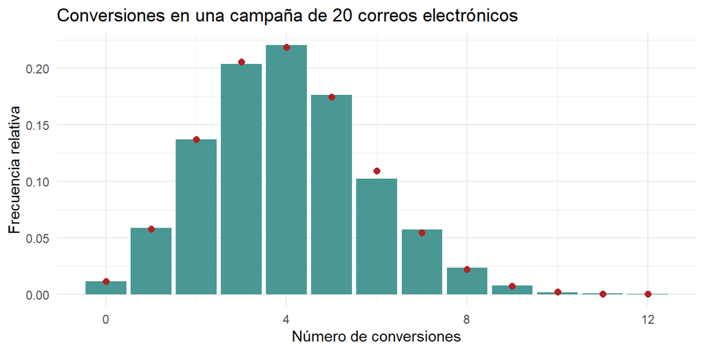

```r
ggplot(campaign_distribution, aes(conversion_count, relative_freq)) +
  geom_col(fill = "#499894") +
  geom_point(aes(y = theoretical), color = "firebrick", size = 2) +
  labs(
    title = "Conversiones en una campaña de 20 correos electrónicos",
    x = "Número de conversiones",
    y = "Frecuencia relativa"
  )
```

### Ejemplo 3: detección de productos defectuosos

Inspeccionamos lotes de 15 artículos donde cada artículo tiene una probabilidad de defecto del 5%. Tras (6000) inspecciones simuladas, comparamos la distribución de los conteos de defectos con la distribución binomial correspondiente.

```r
n_batches <- 6000
batch_size <- 15
defect_prob <- 0.05
defect_counts <- rbinom(n = n_batches, size = batch_size, prob = defect_prob)

defect_distribution <- tibble(defects = defect_counts) %>%
  count(defects) %>%
  mutate(relative_freq = n / sum(n),
         theoretical = dbinom(defects, size = batch_size, prob = defect_prob))

defect_distribution %>% slice_head(n = 6)
```

```
## # A tibble: 6 × 4
##   defects     n relative_freq theoretical
##     <int> <int>         <dbl>       <dbl>
## 1       0  2750      0.458       0.463
## 2       1  2216      0.369       0.366
## 3       2   828      0.138       0.135
## 4       3   173      0.0288      0.0307
## 5       4    32      0.00533     0.00485
## 6       5     1      0.000167    0.000562
```

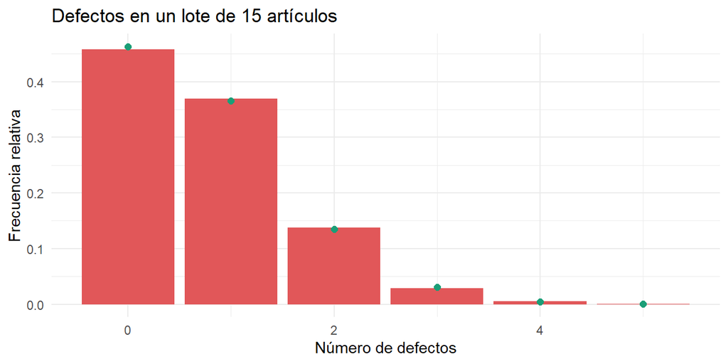

```r
ggplot(defect_distribution, aes(defects, relative_freq)) +
  geom_col(fill = "#E15759") +
  geom_point(aes(y = theoretical), color = "#1B9E77", size = 2) +
  labs(
    title = "Defectos en un lote de 15 artículos",
    x = "Número de defectos",
    y = "Frecuencia relativa"
  )
```

## Distribución hipergeométrica

### Teoría

La distribución hipergeométrica mide el número de éxitos en $n$ extracciones de una población finita **sin reemplazo**. Si una población tiene $N$ elementos con $K$ éxitos y $N - K$ fracasos, y extraemos $n$ elementos, entonces para $k$ éxitos la pmf es

$$P(X = k) = \frac{\binom{K}{k} \binom{N - K}{n - k}}{\binom{N}{n}},
\qquad \max(0,, n - (N - K)) \le k \le \min(n,, K).$$

La esperanza y la varianza incorporan la corrección por población finita:

$$\mathbb{E}[X] = n \frac{K}{N}, \qquad \operatorname{Var}(X) = n
\frac{K}{N} \left(1 - \frac{K}{N}\right) \frac{N - n}{N - 1}.$$

Esta distribución es adecuada cuando las selecciones se realizan sin reemplazo, como al sacar cartas de una baraja o muestrear unidades de un lote.

### Ejemplo 1: sacar ases de una baraja

Extraemos cinco cartas de una baraja estándar de 52 cartas. El número de ases en la muestra sigue una distribución hipergeométrica con (N = 52), (K = 4) y (n = 5).

```r
n_samples <- 7000
num_aces <- rhyper(nn = n_samples, m = 4, n = 52 - 4, k = 5)

aces_distribution <- tibble(aces = num_aces) %>%
  count(aces) %>%
  mutate(relative_freq = n / sum(n),
         theoretical = dhyper(aces, m = 4, n = 48, k = 5))

aces_distribution
```

```
## # A tibble: 4 × 4
##    aces     n relative_freq theoretical
##   <int> <int>         <dbl>       <dbl>
## 1     0  4674       0.668       0.659
## 2     1  2038       0.291       0.299
## 3     2   276       0.0394      0.0399
## 4     3    12       0.00171     0.00174
```

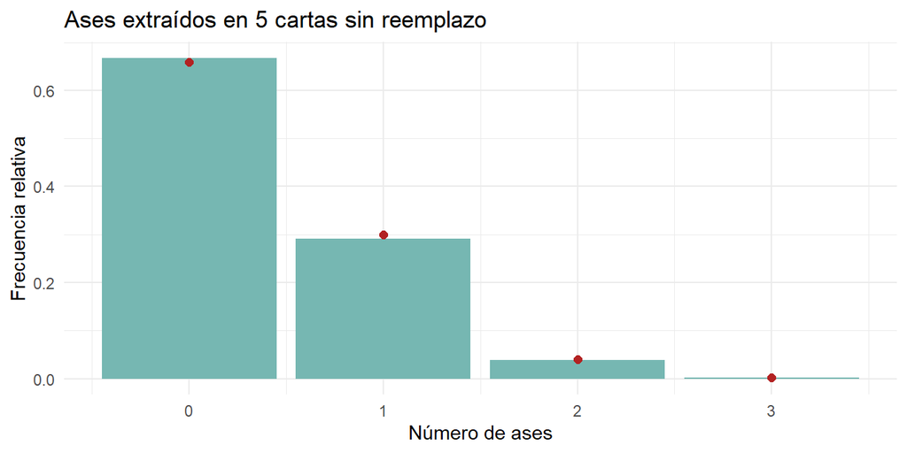

```r
ggplot(aces_distribution, aes(aces, relative_freq)) +
  geom_col(fill = "#76B7B2") +
  geom_point(aes(y = theoretical), color = "firebrick", size = 2) +
  labs(
    title = "Ases extraídos en 5 cartas sin reemplazo",
    x = "Número de ases",
    y = "Frecuencia relativa"
  )
```

### Ejemplo 2: muestreo de un lote sin reemplazo

Un lote contiene (N = 40) artículos, de los cuales (K = 8) son defectuosos. Un inspector toma una muestra de (n = 10) artículos sin reemplazo y cuenta los defectos.

```r
n_inspections <- 8000
lot_defects <- rhyper(nn = n_inspections, m = 8, n = 32, k = 10)

lot_distribution <- tibble(defects = lot_defects) %>%
  count(defects) %>%
  mutate(relative_freq = n / sum(n),
         theoretical = dhyper(defects, m = 8, n = 32, k = 10))

lot_distribution
```

```
## # A tibble: 8 × 4
##   defects     n relative_freq theoretical
##     <int> <int>         <dbl>       <dbl>
## 1       0   618      0.0772     0.0761
## 2       1  2137      0.267      0.265
## 3       2  2738      0.342      0.347
## 4       3  1784      0.223      0.222
## 5       4   584      0.073      0.0748
## 6       5   121      0.0151     0.0133
## 7       6    17      0.00213    0.00119
## 8       7     1      0.000125   0.0000468
```

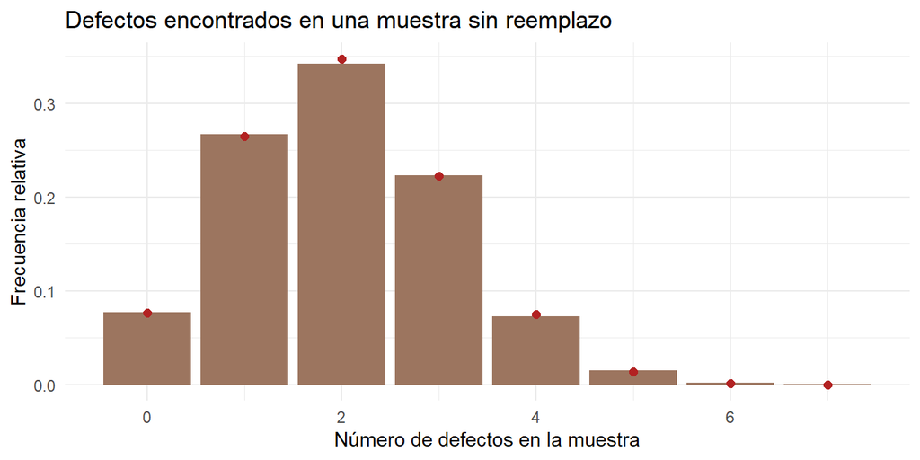

```r
ggplot(lot_distribution, aes(defects, relative_freq)) +
  geom_col(fill = "#9C755F") +
  geom_point(aes(y = theoretical), color = "firebrick", size = 2) +
  labs(
    title = "Defectos encontrados en una muestra sin reemplazo",
    x = "Número de defectos en la muestra",
    y = "Frecuencia relativa"
  )
```

## Conclusiones

En estos ejemplos, las frecuencias simuladas se alinean estrechamente con las pmf teóricas de cada distribución una vez que reunimos una muestra suficientemente grande. Las distribuciones uniforme y de Bernoulli tratan ensayos individuales, mientras que las distribuciones binomial e hipergeométrica se extienden al conteo de éxitos a lo largo de múltiples extracciones—con y sin reemplazo, respectivamente. Las simulaciones ilustran cómo la variación aleatoria se manifiesta en muestras finitas y proporcionan una verificación empírica de los modelos teóricos.